# Quiz 3

2023-12-12

## 시험시간: 2023년 12월 12일 13:10 ~ 14:40

## 제출: Html, Rmd 파일을 .zip으로 압축해 etl에 제출

#### 주의사항

- 전자기기(휴대폰 등)나 메신저(메일, 카톡 등)는 시험 중 절대로 사용할 수 없음. 사용이 적발 시 부정행위로 간주해 바로 퇴실조치.
- 시간 초과로 인해 제출하지 못하는 경우 책임은 수강생 본인에게 있음. 마감 시간 까지 문제를 푸는 것이 아닌, Knit과 etl 제출까지 완료해야 하므로 꼭 마지막 5~10분은 제출 준비 할 것.

```r
library(tidyverse)
library(quantmod)
```

### Q1. 콜라츠 추측은 임의의 자연수가 다음 함수를 여러번 거치면 항상 1이 된다는 추측이다. 예를 들어, 6에서 시작한다면, 차례로 6, 3, 10, 5, 16, 8, 4, 2, 1 이 된다.

$$T(n)=\left\{\begin{array}{cc}
\frac{n}{2}, & \text { if } n \text { is even } \\
3 n+1, & \text { if } n \text { is odd }
\end{array}\right.$$

### 다음 조건에 따라 콜라츠 추측을 구현하는 함수를 만드시오.

- 조건 1. 함수의 input은 자연수로 하고 output은 모든 숫자(`number`)와 시행 횟수(`trial`)가 나오도록 한다. input이 자연수가 아닌 경우 에러 메세지를 출력하도록 한다.
- 조건 2. 반복문을 사용할 것.
- 조건 3. 함수를 구현한 뒤 `436712387`를 넣어 결과값을 저장하고 `tail`함수로 출력하시오. 또한 아래 그림과 같이 콜라츠 추측을 시각화하시오. 마지막 점의 시행 횟수와 숫자를 plot 상에 표시할 것.
- 조건 4. `100.5`를 함수에 넣어 에러 메세지를 출력하시오.

아래 그림은 500을 함수에 넣었을 때 나온 값의 예시

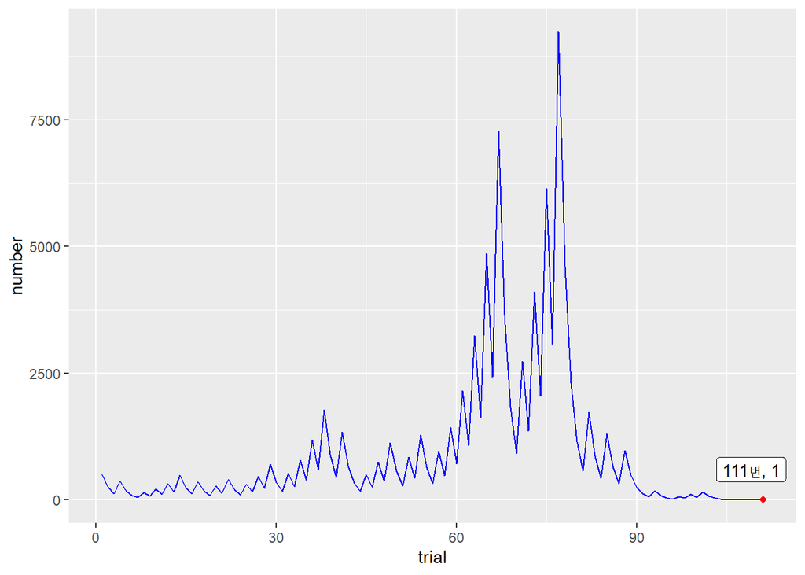

### Q2. `lubridate::lakers` 는 08-09 시즌 LA 레이커스 농구팀의 시즌동안의 기록들이 들어있는 데이터이다. 본 문제에서는 아래 나열된 10개의 변수들만 사용하시오.

- `date` : 경기 날짜
- `opponent` : 상대팀
- `game_type` : 홈 & 어웨이 경기
- `time` : 각 퀴터 남은시간
- `period` : 쿼터
- `etype` : 현재 경기 상황 (자유투를 시도한 경우 `etype == "free throw"` 가 된다)
- `team` : 현재 `etype` 을 하고 있는 팀 (LA 레이커스의 경우 `team == "LAL"` 이다.)
- `player` : `etype` 을 한 선수이름
- `result` : `etype` 의 `shot`,`free throw` 의 경우 성공여부
- `points` : 득점하였을 경우 득점양

아래 예시는 `lubridate::lakers` 의 6번째 행으로 2008년 10월 28일(`date`)에 LAL(`team`)의 Pau Gasol(`Player`) 선수가 POR(`opponent`)팀을 상대로 2점(`points`) 슛 (`etype`)을 성공(`result`)시켰음을 의미한다.

```r
lubridate::lakers[6,1:10]
```

```
##       date opponent game_type  time period etype team    player result points
## 6 20081028      POR      home 11:22      1  shot  LAL Pau Gasol   made      2
```

#### 2-1. LA 레이커스가 각 상대팀들과 대결할때 각 팀별로 넣은 평균득점을 알아보고자 한다. 상대팀에 따른 평균 득점을 시각화하시오.

- 조건 1. 평균득점 순서대로 나열되게 그리시오

#### 2-2. LA 레이커스에서 이번 시즌 자유투 시도를 누가 제일 많이 했는지를 알아보고자 한다. 자유투 시도 (etype = free throw) 횟수가 제일 많은 10명은 누구인가?

- 조건 1. 10명의 선수들을 자유투 시도 횟수와 함께 도표로 나타낼 것

#### 2-3. LA 레이커스의 경기별 득점양을 date 순서로 된 그래프로 나타내어라.

### Q3. `quantmod` package에서 추출한 아래 `stock` 자료는 테슬라(TSLA) 주식의 최근 2000일에 거친 가격을 나타낸다. 투자 가능 기간을 입력(input)했을 때, 기간 내에서 가장 높은 수익률을 얻을 수 있는 구매 날짜, 판매 날짜, 수익률에 대한 메세지를 출력(output)해주는 `invest` 라는 이름의 함수를 조건에 맞게 구현하시오.

패키지를 부착하고 아래 코드를 이용해 `stock` 이라는 dataframe을 생성하시오.

```r
stockdata <-
  getSymbols(
    Symbols = "TSLA",
    src = "yahoo",
    from = Sys.Date() - 2000,
    to = Sys.Date(),
    auto.assign = FALSE
  )
stock_date <- as.character(index(stockdata))
stock_price <- coredata(stockdata)[, 4]
stock <- as.data.frame(cbind(stock_date, stock_price))
stock$stock_price <- as.numeric(stock$stock_price)

head(stock, 10)
```

```
##    stock_date stock_price
## 1  2018-06-21    23.16733
## 2  2018-06-22    22.24200
## 3  2018-06-25    22.20067
## 4  2018-06-26    22.80000
## 5  2018-06-27    22.96667
## 6  2018-06-28    23.32867
## 7  2018-06-29    22.86333
## 8  2018-07-02    22.33800
## 9  2018-07-03    20.72400
## 10 2018-07-05    20.61067
```

- 조건 1. 함수는 `invest<-function(start_date, end_date){` 에서 시작하여 구현하여라. start_date, end_date는 투자 가능 기간을 나타내는 입력값으로 chr형태(ex.invest(‘2022-01-28’,‘2023-08-31’))로 입력된다.
- 조건 2. return 값으로는 입력한 투자 가능 기간 내에서 가장 높은 수익률을 얻을 수 있는 주식 구매 날짜와 판매 날짜, 이 기간에 상응되는 수익률(반올림하여 소수점 둘째 자리까지 나타내어라) 이 포함된 메세지를 형식에 맞게 출력하여라. 출력되는 메세지의 형식은 다음과 같다.  
  형식: Buy stock on 2022-02-03, and sell it on 2023-01-13 that earns 125.35%.
- 조건 3. 주식 보유 기간 (구매 날짜부터 판매 날짜 까지의 기간)이 50일 미만인 경우는 고려하지 않는다. 또한 입력값인 투자 가능 기간이 50일 미만의 기간으로 입력되는 경우 `'Period input error'`를 출력하여라. `stock` 자료는 주식시장이 열리는 평일 데이터만 나타내지만 주식 보유 기간에는 주말과 공휴일도 포함됨에 유의하여라.
- 조건 4. 만약 어떤 기간을 잡아도 손실이 발생하는 경우 `'Do not invest'` 를 출력하여라. (주식 가격이 소수점 다섯째 자리까지 주어지므로 서로 다른 기간에서 수익률이 같아지는 경우는 고려하지 않는다)
- 조건 5. (중요) 채점 데이터 대입을 위해 데이터프레임 이름 `stock`과 colnames `stock_date`, `stock_price`, 함수 이름 `invest` 을 절대로 임의로 변경하지 말것.
- 조건 6. `invest('2022-01-28','2023-08-31')`, `invest('2022-09-16','2023-01-06')`, `invest('2019-06-30','2022-06-30')`,  
  `invest('2022-09-16','2022-10-30')`, `invest('2021-11-05','2023-01-06')`의 결과를 차례로 출력하여라.
- 힌트 1. 주식의 수익은 비율로 계산되어야 한다. 예를 들어 주식 가격이 100에서 200이 되면 수익률은 100% 이지만 500에서 600이 되면 수익률은 20% 이다.